# Integral de Convolução

Renato Naville Watanabe

Aqui, vamos desenvolver um método para encontrar a saída $y(t)$ de um sistema contínuo linear e invariante no tempo para uma entrada $x(t)$ qualquer.

[figure not shown]

Vamos considerar que conhecemos a resposta ao impulso do sistema.

[figure not shown]

Como o sistema é linear e invariante no tempo se usarmos como entrada o impulso de Dirac multiplicado por um valor real e atrasado em alguma quantidade de tempo ($\alpha\delta(t-T)$), a saída será $\alpha h(t-T)$ (multiplicada pelo mesmo valor e atrsada da mesma quantidade de tempo).

[figure not shown]

Em sinais de tempo contínuo, pelo terorema da amostragem, podemos escrever o valor de $x(t)$ em algum instante específico como:

$$x(\tau) = x(\tau)\delta(t-\tau)$$

Então ao usar $x(\tau)$ como entrada, a saída é $x(\tau)h(t-\tau)$

[figure not shown]

O sinal $x(t)$ todo pode ser escrito como a soma (integral, já que é um sinal contínuo) dos valores em cada instante. Então podemos reescrever o sinal $x(t)$ como:

$$x(t) = \int_{-\infty}^\infty x(\tau)\delta(t-\tau)\,d\tau$$

Ou seja, o sinal $x(t)$ é a integral de impulsos deslocados no tempo.

Então, considerando o exposto acima e o princípio da superposição que sistemas lineares e invariantes no tempo obedecem, temos que a saída do sistema será:

$$y(t) = \int_{-\infty}^\infty x(\tau)h(t-\tau)\,d\tau $$

Esta relação está representada na imagem abaixo:

[figure not shown]

Esta expressão é central no desenvolvimento da teoria de sistemas e sinais de tempo contínuo e recebe o nome de **integral de convolução**.

A integral de convolução é uma operação entre dois sinais (no caso acima $x(t)$ e $h(t)$) e é representada pelo operador *.

$$y(t) = \int_{-\infty}^\infty x(t)h(t-\tau)\,d\tau = x(t)*h(t)$$

Perceba que o símbolo * é apenas uma forma reduzida de representar a integral de convolução (nunca se deve confundir com a simples multiplicação dos valores de $x$ e $h$ no instante $t$).

## Forma de calcular a integral de convolução

### Método gráfico

Esse método, por ser mais simples de se computar, é mais utilizado para calcular a convolução. Vamos voltar para a expressão da convolução:

$$y(t) = x(t)*h(t) = \int_{-\infty}^\infty x(t)h(t-\tau)\,d\tau$$

Podemos enxergar os sinais como sendo função de $\tau$ ao invés de $t$. Então, para $t = 0$, temos os dois sinais a ser considerado: $x(t)$ e $h(-t)$ (a resposta ao impulso espelhada).

Vamos fazer a convolução entre

$$x(t) = 2u(t) - 2u(t-1)$$

e

$$h(t) = tu(t) - tu(t-2)$$

```
Manim Community v0.17.3
```

[output not shown]

[video not shown]

#### Resumo dos passos

1 - substituir $t$ por $\tau$ e fazer o gráfico de $x(\tau)$ e $h(-\tau)$.

2 - Deslocar $h[-\tau]$ para a direita em algumas unidades de tempo para gerar $h(t-\tau)$ até um ponto em que $h(t-\tau)$ não se sobreponha a $x(\tau)$. Multiplique os dois sinais e calcule a integral (área) do sinal resultante para encontrar o valor de $y(t)$.

3 - Continue deslocando $h(-\tau)$ para a direita, multiplicando o sinal $x(t)$ com a resposta ao impulso deslocada e calculando a sua integral para encontrar os valores de $y(t)$. Continue fazendo isso até não ter mais sobreposição entre os sinais.

### Pelo cálculo da integral

Muitas vezes, é mais fácil calcular a integral de convolução diretamente, sem recorrer ao método gráfico. Por exemplo:

$$x(t) = e^{-bt}u(t)$$

e

$$h(t) = e^{-at}u(t)$$

A integral de convolução entre esses dois sinais é:

$$x(t)*h(t) = \int_{-\infty}^\infty e^{-b\tau}u(\tau)e^{-a(t-\tau)}u(t-\tau)\,d\tau=\int_{0}^t e^{-b\tau}e^{-a(t-\tau)}\,d\tau = e^{at}\int_{0}^t e^{-b\tau}e^{a\tau)}\,d\tau $$$$x(t)*h(t) = e^{at}\int_{0}^t e^{(a-b)\tau}\,d\tau = \left. e^{at}\left( \frac{e^{(a-b)\tau}}{a-b}\right)\right|_{\tau=0}^t\frac{e^{-bt}-e^{-at}}{a-b}$$

Para $a=2$ e $b=5$, o gráfico dessa convolução é:

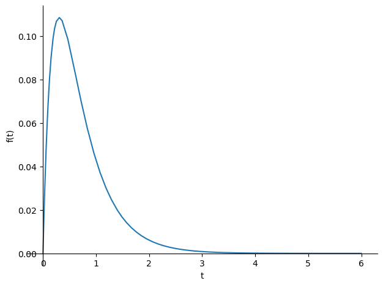

```
<sympy.plotting.plot.Plot at 0x7fd124cd1070>
```

É claro que poderíamos ter feito essa convolução com o método gráfico também.

[video not shown]

[output not shown]

## Caracterização de um SLIT pela resposta ao impulso

A principal consequência da integral de convolução é que conseguimos caracterizar completamente um sistema linear e invariante no tempo de contínuo pela sua resposta ao impulso. Perceba que não é necessário conhecer a equação de diferenças nem o diagrama de blocos do sistema se tivermos a resposta ao impulso. Portanto, **a resposta ao impulso caracteriza completamente o comportamento de um sistema linear e invariante no tempo**.

Por isso, é bastante comum no diagrama de blocos representar o sistema pela sua respsota ao impulso.

[figure not shown]

## Propriedades da convolução

### Comutativa

Uma das propriedades mais importantes, principalmente do ponto de vista prático, já que pode facilitar a computação da conolução.

> $x(t)*h(t) = h(t)*x(t)$

**Prova**:

Aqui é feita uma mudança de variável ($\upsilon = t-\tau$), e a prova sai facilmente.

$$ x(t)*h(t) = \int_{-\infty}^\infty x(\tau)h(t-\tau)\,d\tau = \int_{-\infty}^\infty x(t-\upsilon)h(\upsilon)\,d\upsilon = h(t)*x(t)$$

### Distributiva

> $x(t)*h_1(t)+x(t)*h_2(t) = x(t)*(h_1(t)+ h_2(t))$

A prova dessa propriedade fica para o Exercício 1.

Com esta propriedade, podemos interpretar dois sistemas ligados em paralelo, recebendo a mesma entrada, como sendo apenas um sistema que tem a resposta ao impulso igual a soma das respostas ao impulso dos dois sistemas ligados em paraleo.

[figure not shown]

Uma outra consequência dessa propriedade é que podemos dividir a resposta ao impulso de um sistema em várias partes se isso facilitar o cálculo da somatória de convolução.

### Associativa

> $x(t)*(h_1(t)*h_2(t)) = (x(t)*h_1(t))*h_2(t)$

A prova dessa propriedade fica para o Exercício 2.

A principal consequência dessa propriedade é que se tivermos dois sistemas em série, podemos considerá-los como um sistema com a resposta ao impulso sendo a convolução das respostas ao impulso dos dois sistemas.

[figure not shown]

## Exercícios

**1)** Prove a propriedade distributiva da integral de convolução.

**2)** Prove a propriedade associativa da integral de convolução

**3)** Seja o sinal $h(t)$:

$$h(t) = e^{3t}u(-t+1) + e^{-3t}u(t-3)$$

Determine os valores de $A$ e $B$ de forma que:

$$h(t-\tau) = \left\{\begin{array}{cc}e^{-3(t-\tau)}&,\tau<A\\0&,A\leq\tau<B \\e^{3(t-\tau)}&,\tau\geq B \end{array} \right.$$

**4)** Determine:

a) $u(t)*u(t)$

b) $e^{-3t}u(t)*u(t)$

c) $tu(t)*u(t)$

d) $\mathrm{sen}(t)u(t)*u(t)$

e) $\cos(t)u(t)*u(t)$

**5)** Determine a resposta de um sistema linear e invariante no tempo (estado nulo) às entradas abaixo, considerando que esse sistema tem a seguinte resposta ao impulso:

$h(t) = e^{-3t}u(t)$

a) $x_1(t) = u(t)$

b) $x_2(t) = e^{-2t}u(t)$

c) $x_3(t) = \cos(2t)u(t)$

**6)** Calcule a resposta do sistema que tem a rersposta ao impulso $h(t)$ mostrada no gráfico abaixo quando é usada a entrada $x(t)$, também mostrada abaixo. Esse sistema é causal?

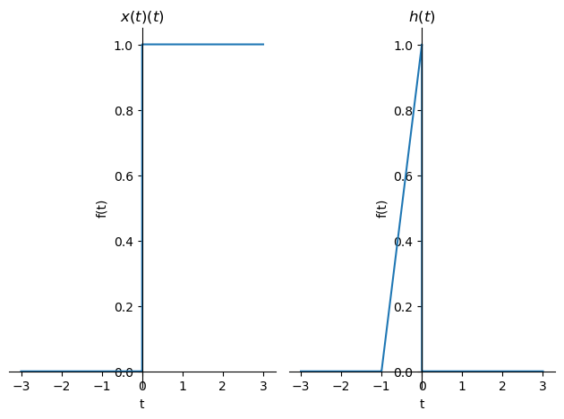

```
<sympy.plotting.plot.PlotGrid at 0x7fd11dd58610>
```

**7)** Considere o circuito elétrico da figura abaixo:

[figure not shown]

Considere que o sinal de entrada do sistema é a tensão do gerador $x(t) = V_{in}$ e o sinal de saída é a tensão no capacitor $y(t)=V_c$. Pede-se:

a) A equação diferencial que descreve o comportamento desse sistema (lembre-se que $I=C\frac{dV_c}{dt}$ e $I = \frac{V_r}{R}$).

b) A resposta ao impulso desse sistema.

c) Determine a resposta de entrada nula, e esboce seu gráfico, considerando que $V_c(0) = 1$ V.

d) Encontre o sinal de saída, levando em conta a sua condição inicial, para o sinal de entrada $x(t) = e^{-t}u(t)$ V.

**8)** Qual o comportamento esperado (descreva em palavras, justificando) de um sistema que tenha como resposta ao impulso as seguintes funções:

a) $h_1(t) = u(t)$

b) $h_2(t) = \delta(t)$

## Referências

- Ulaby, FT e Yagle, AE, Signals & Systems: Theory and Applications, 2018, ss2.eecs.umich.edu
- Oppenheim, M. e Willsky, S., Sistemas e Sinais, 2010
- Lathi, BP, Sinais e Sistemas Lineares, 2007